# Python Basics

```python
print("Welcome to Python Programming")
```

```
Welcome to Python Programming
```

```python
print('Hello Programmers')
```

```
Hello Programmers
```

```python
10 + 20
```

```
30
```

```python
'Abhisheak Saraswat'
```

```
'Abhisheak Saraswat'
```

## Note:

In Python programming, we can enclosed the string either in single or double quotes.

```python
'a' == "a"
```

```
True
```

### Note:

Python programming is a case-sensitive programming language.

```python
'A' == 'a'
```

```
False
```

```python
10 == 10
```

```
True
```

```python
'Ojha' == 'ojha' # to compare the two thing which are equal or not.
```

```
False
```

```python
# esc m : Markdown and esc y : code env
```

### Python Keywords

Keywords are reserve words in Python for specific use.

**Note:** We can recognize the keywords in jupyter notebook in **green color with bold** .

```python
import keyword
```

```python
print(keyword.kwlist)
```

```
['False', 'None', 'True', 'and', 'as', 'assert', 'async', 'await', 'break', 'class', 'continue', 'def', 'del', 'elif', 'else', 'except', 'finally', 'for', 'from', 'global', 'if', 'import', 'in', 'is', 'lambda', 'nonlocal', 'not', 'or', 'pass', 'raise', 'return', 'try', 'while', 'with', 'yield']
```

```python
print(dir(__builtins__))
```

```
['ArithmeticError', 'AssertionError', 'AttributeError', 'BaseException', 'BaseExceptionGroup', 'BlockingIOError', 'BrokenPipeError', 'BufferError', 'BytesWarning', 'ChildProcessError', 'ConnectionAbortedError', 'ConnectionError', 'ConnectionRefusedError', 'ConnectionResetError', 'DeprecationWarning'…
```

### Python Variables:

Variables are containers which can hold **some piece of information**. In Python programming variables types determined based on the nature of the data thats why we are calling Python is a **dynamic semantic programming language** as well.

```python
i = 32767
```

```python
type(i)
```

```
int
```

```python
i = 8279457238945729347529837452937459202710025289734952734
```

```python
type(i)
```

```
int
```

```python
i = 'Abhisheak'
```

```python
type(i)
```

```
str
```

```python
i = 12.24938502934850293485902385092829438945
type(i)
```

```
float
```

```python
i = True
type(i)
```

```
bool
```

```python
i = 3 + 4j
type(i)
```

```
complex
```

```python
# 10 whole number
# 10.50 Float
```

### Python Operators:

- Types of operators:
  - Airthmetic Operator
  - Logical Operator
  - Comparision Operator
  - Identity Operator
  - Membership Operator
  - BitWise Operator

## Airthmetic Operator:

+,-,*,/,**,//,%

```python
a = 10
b = 20
```

```python
a + b
```

```
30
```

```python
a - b
```

```
-10
```

```python
a * b
```

```
200
```

```python
b / a
```

```
2.0
```

```python
5 ** 2
```

```
25
```

```python
pow(5,2)
```

```
25
```

```python
# floor division
```

```python
17 // 4
```

```
4
```

```python
351 // 39
```

```
9
```

```python
19 // 3
```

```
6
```

### Modulus :

Gives remainder.

```python
19 % 4
```

```
3
```

```python
16 % 2
```

```
0
```

### Note:

Jupyter notebook will give you by default last statement result.

```python
print(17 % 3)
print(19 % 5)
print(10 + 5)
```

```
2
4
15
```

```python
print("We are learning Python Programming at upGrad!!!")

print("We are learning Python Programming at upGrad!!!")
```

```
We are learning Python Programming at upGrad!!!
We are learning Python Programming at upGrad!!!
```

### Comparision Operator and Assignment Operator

> ,<,>=,<=,=,==,!=

```python
5 >= 3
```

```
True
```

```python
5 == 7
```

```
False
```

```python
7 != 7
```

```
False
```

```python
10 <= 5
```

```
False
```

```python
10 >= -20
```

```
True
```

```python
a = 100
```

### Logical Operators

- and : All the conditions must be statisfy as True then result will be True
- or : Any conditions evaluted as True then result will be True
- not : True result evaluated as False and vice-versa.

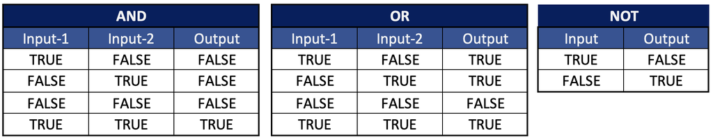

```python
(5 >= 1) and (10 <= 50)
```

```
True
```

```python
(10 == 10) and ("A" == "A") or (5 >= 5) and (6 >= 10)
```

```
True
```

```python
5 >= 3
```

```
True
```

```python
not(5>=3)
```

```
False
```

```python
not(5 == 9)
```

```
True
```

```python
((10 == 10) and ("A" == "A")) or ((5 >= 5) and (6 >= 10))
```

[output not shown]

```python
(10 == 10) and (("A" == "A") or ((5 >= 5) and (6 >= 10)))
```

```
True
```

### Membership Operator:(in)

Using this operation we can check the item existence in the dataset.

```python
st = "We are learning Python Programming"
```

```python
'thon' in st
```

```
True
```

```python
'Are' in st
```

```
False
```

```python
'Modi' in st
```

```
False
```

```python
'Modi' not in st
```

```
True
```

```python
'Python' in st
```

```
True
```

### Identity Operator : 'is'

```python
a = 20
```

```python
a is 20
```

```
True
```

```python
a == 20
```

```
True
```

```python
10 is 10
```

```
True
```

```python
'A' is 'a'
```

```
False
```

### BitWise Operator

- & (bitwise and)
- | (bitwise or)

```python
7 & 5
```

```
5
```

```python
5 & 7
```

```
5
```

```python
10 & 5
```

```
0
```

```python
10 | 5
```

```
15
```

```python
# 7 & 5
7 & 5
```

```
5
```

```python
# what is the binary of 7 and 5 :
# In Binary: 1 -> True and 0 -> False
```

```python
bin(7)
```

```
'0b111'
```

```python
bin(5)
```

```
'0b101'
```

```python
1 1 1
1 0 1 &
______
1 0 1
```

```python
print(0b101)
```

```
5
```

```python
bin(10)
```

```
'0b1010'
```

```python
bin(5)
```

```
'0b101'
```

```python
1 0 1 0
0 1 0 1 |
_________
1 1 1 1
```

```python
print(0b1111)
```

```
15
```

```python
10 | 5
```

```
15
```

```python
1 0 1 0
0 1 0 1 &
_________
0 0 0 0
```

```python
10 & 5
```

```
0
```

```python
7 & 3
```

```
3
```

```python
1 1 1
0 1 1
______
0 1 1
```

```python
print(0b011)
```

```
3
```

```python
# Number to Binary
# Binary to Number
```

```python
name = "Pallavi shree"
```

```python
'sh' in name
```

```
True
```

```python
lst = ['Modi','Biden','Trump','Jocinda']
```

```python
'Trump' in lst
```

```
True
```

```python
lst = [12,56,78,9,0,2,3,4,5,6,7,8,9100,100]
```

```python
100 in lst
```

```
True
```

```python
99 in lst
```

```
False
```

### F-String | Formatted String

```python
a = 10; b = 20
```

```python
print(f"The value of a is {a} and b is {b}.")
```

```
The value of a is 10 and b is 20.
```

```python
print("The value of a is {0} and b is {1}.".format(a,b))
```

```
The value of a is 10 and b is 20.
```

```python
print("Ankit")
print("Kumar")
```

```
Ankit
Kumar
```

```python
print("Ankit",end = "\n") # shift + tab
# \n -> new line
print("Kumar")
```

```
Ankit
Kumar
```

```python
print("Ankit", end = " ")
print("Kumar")
```

```
Ankit Kumar
```

```python
print("Ankit\nKumar")
```

```
Ankit
Kumar
```

```python
print("Som")
print("Singh")
```

```
Som
Singh
```

```python
print("Som", end = " | ")
print("Singh")
```

```
Som | Singh
```

```python
print("Som", end = " | Singh")
```

```
Som | Singh
```

### Printing Quotation marks:

```python
"It's raining outside."
```

```
"It's raining outside."
```

```python
"He said, "Python is awesome!"
```

```
  Cell In[250], line 1
    "He said, "Python is awesome!"
                                 ^
SyntaxError: unterminated string literal (detected at line 1)
```

```python
"He said, 'Python is awesome'"
```

```
"He said, 'Python is awesome'"
```

```python
'He said,"Python is awesome".'
```

```
'He said,"Python is awesome".'
```

```python
'He said, \'Python is awesome\''
```

```
"He said, 'Python is awesome'"
```

### Conclusion:

In today session, we discussed about basics of Python, more specifically we discussed follows:

- Python Variables
- Python Data Type
- Python Operators
- Python F-String